# Medevac Interrater Reliability Study

Final Report

Author

Medevac Interrater Study Team

Published

December 4, 2025

# Study Overview

## Table 1: Study Composition

This table provides a comprehensive overview of the study design, organized into two sections: Vignettes and Respondents.

Study Composition: Vignettes, Respondents, and Response Metrics

| **VIGNETTES** |  |
| --- | --- |
| Total Vignettes | 20 |
| Class A (One Correct Answer) | 8 |
| Medevac | 4 |
| Commercial | 2 |
| Remain | 2 |
| Class B (Two Reasonable Options) | 9 |
| Medevac or Commercial | 2 |
| Commercial or Remain | 4 |
| Medevac or Remain | 3 |
| Class C (Highly Ambiguous) | 3 |
| All Options Reasonable | 3 |
| **RESPONDENTS** |  |
| Total Physicians | 20 |
| By Affiliation: |  |
| ANMC | 10 |
| Maniilaq | 8 |
| Other | 2 |
| Years Since Training: |  |
| Mean (SD) | 9.6 (7.6) |
| Median | 8 |
| Range | 1-30 |
| **RESPONSES** |  |
| Total Responses | 400 |

**Note:** This table summarizes the complete study composition with 20 unique clinical vignettes evaluated by 20 physicians (mean experience: 9.6 years since training completion), generating 400 total responses.

## Figure 1: Response Distribution by Physician

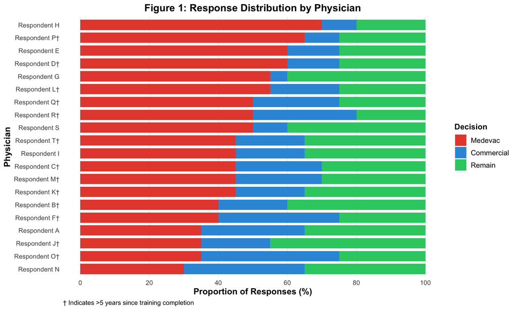

## Overall Results

Mean Agreement %: 74.5%

Median Agreement %: 75%

Agreement Range: 45% - 100%

Mean Confidence: 7.8

Mean Entropy: 0.786

Vignettes with >=75% Agreement: 13

Vignettes with <50% Agreement: 3

## Tables 2.1-2.3: Summary Statistics by Individual Vignette

These tables show detailed statistics for each vignette organized by class, with response distributions presented as percentage and count (% (n=)).

Table 2.1: Class A - One Correct Answer

| Subclass | Question Number | Medevac | Commercial | Remain | Modal Decision | Agreement % | Gwet's AC1 | Interpretation | Entropy | Mean Conf. |
| --- | --- | --- | --- | --- | --- | --- | --- | --- | --- | --- |
| Medevac | 1 | 100.0% (n=20) | 0.0% (n=0) | 0.0% (n=0) | Medevac | 100 | 1.000 | Perfect | 0.000 | 9.3 |
| Medevac | 4 | 95.0% (n=19) | 0.0% (n=0) | 5.0% (n=1) | Medevac | 95 | 0.889 | Very Good | 0.286 | 8.8 |
| Medevac | 13 | 100.0% (n=20) | 0.0% (n=0) | 0.0% (n=0) | Medevac | 100 | 1.000 | Perfect | 0.000 | 9.3 |
| Medevac | 19 | 100.0% (n=20) | 0.0% (n=0) | 0.0% (n=0) | Medevac | 100 | 1.000 | Perfect | 0.000 | 9.0 |
| Commercial | 9 | 0.0% (n=0) | 75.0% (n=15) | 25.0% (n=5) | Commercial | 75 | 0.368 | Fair | 0.811 | 7.3 |
| Commercial | 15 | 65.0% (n=13) | 30.0% (n=6) | 5.0% (n=1) | Medevac | 65 | 0.326 | Fair | 1.141 | 7.7 |
| Remain | 8 | 5.0% (n=1) | 15.0% (n=3) | 80.0% (n=16) | Remain | 80 | 0.576 | Moderate | 0.884 | 7.3 |
| Remain | 11 | 0.0% (n=0) | 25.0% (n=5) | 75.0% (n=15) | Remain | 75 | 0.368 | Fair | 0.811 | 7.2 |

Table 2.2: Class B - Two Reasonable Options

| Subclass | Question Number | Medevac | Commercial | Remain | Modal Decision | Agreement % | Gwet's AC1 | Interpretation | Entropy | Mean Conf. |
| --- | --- | --- | --- | --- | --- | --- | --- | --- | --- | --- |
| Medevac or Commercial | 7 | 95.0% (n=19) | 5.0% (n=1) | 0.0% (n=0) | Medevac | 95 | 0.889 | Very Good | 0.286 | 9.4 |
| Medevac or Commercial | 10 | 70.0% (n=14) | 30.0% (n=6) | 0.0% (n=0) | Medevac | 70 | 0.238 | Fair | 0.881 | 8.0 |
| Commercial or Remain | 2 | 20.0% (n=4) | 45.0% (n=9) | 35.0% (n=7) | Commercial | 45 | 0.021 | Slight | 1.513 | 7.2 |
| Commercial or Remain | 5 | 0.0% (n=0) | 75.0% (n=15) | 25.0% (n=5) | Commercial | 75 | 0.368 | Fair | 0.811 | 7.7 |
| Commercial or Remain | 6 | 25.0% (n=5) | 45.0% (n=9) | 30.0% (n=6) | Commercial | 45 | -0.002 | None | 1.539 | 7.0 |
| Commercial or Remain | 14 | 0.0% (n=0) | 20.0% (n=4) | 80.0% (n=16) | Remain | 80 | 0.505 | Moderate | 0.722 | 7.4 |
| Medevac or Remain | 16 | 75.0% (n=15) | 0.0% (n=0) | 25.0% (n=5) | Medevac | 75 | 0.368 | Fair | 0.811 | 7.2 |
| Medevac or Remain | 17 | 50.0% (n=10) | 0.0% (n=0) | 50.0% (n=10) | Medevac | 50 | -0.053 | None | 1.000 | 7.0 |
| Medevac or Remain | 18 | 25.0% (n=5) | 0.0% (n=0) | 75.0% (n=15) | Remain | 75 | 0.368 | Fair | 0.811 | 8.3 |

Table 2.3: Class C - Highly Ambiguous

| Subclass | Question Number | Medevac | Commercial | Remain | Modal Decision | Agreement % | Gwet's AC1 | Interpretation | Entropy | Mean Conf. |
| --- | --- | --- | --- | --- | --- | --- | --- | --- | --- | --- |
| All Options Reasonable | 3 | 20.0% (n=4) | 0.0% (n=0) | 80.0% (n=16) | Remain | 80 | 0.505 | Moderate | 0.722 | 6.9 |
| All Options Reasonable | 12 | 45.0% (n=9) | 40.0% (n=8) | 15.0% (n=3) | Medevac | 45 | 0.065 | Slight | 1.458 | 6.2 |
| All Options Reasonable | 20 | 65.0% (n=13) | 25.0% (n=5) | 10.0% (n=2) | Medevac | 65 | 0.289 | Fair | 1.236 | 7.1 |

**Note:** Each vignette was evaluated by 20 physicians. Agreement % (highlighted in green ≥75%, orange 50-74%, red <50%) indicates the percentage who selected the modal decision. Entropy measures disagreement (0 = perfect agreement, higher = more disagreement).

## Figure 2: Agreement and Confidence by Subclass

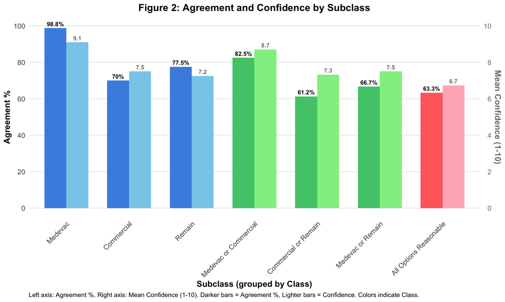

## Tables 3.1-3.3: Summary Statistics by Individual Vignette (High Confidence Only, n=20)

These tables show detailed statistics for each vignette, including only responses with confidence scores of 8 or higher.

### Table 3.1: One Correct Answer (High Confidence Only)

Table 3.1: Class A - One Correct Answer (Confidence >= 8)

| Subclass | Question Number | Medevac | Commercial | Remain | Modal Decision | Agreement % | Gwet's AC1 | Interpretation | Entropy | Mean Conf. |
| --- | --- | --- | --- | --- | --- | --- | --- | --- | --- | --- |
| Medevac | 1 | 100.0% (n=19) | 0.0% (n=0) | 0.0% (n=0) | Medevac | 100.0 | 1.000 | Perfect | 0.000 | 9.7 |
| Medevac | 4 | 100.0% (n=18) | 0.0% (n=0) | 0.0% (n=0) | Medevac | 100.0 | 1.000 | Perfect | 0.000 | 9.5 |
| Medevac | 13 | 100.0% (n=19) | 0.0% (n=0) | 0.0% (n=0) | Medevac | 100.0 | 1.000 | Perfect | 0.000 | 9.5 |
| Medevac | 19 | 100.0% (n=18) | 0.0% (n=0) | 0.0% (n=0) | Medevac | 100.0 | 1.000 | Perfect | 0.000 | 9.5 |
| Commercial | 9 | 0.0% (n=0) | 66.7% (n=8) | 33.3% (n=4) | Commercial | 66.7 | 0.127 | Slight | 0.918 | 8.9 |
| Commercial | 15 | 83.3% (n=10) | 16.7% (n=2) | 0.0% (n=0) | Medevac | 83.3 | 0.580 | Moderate | 0.650 | 9.5 |
| Remain | 8 | 0.0% (n=0) | 7.7% (n=1) | 92.3% (n=12) | Remain | 92.3 | 0.821 | Very Good | 0.391 | 8.6 |
| Remain | 11 | 0.0% (n=0) | 25.0% (n=3) | 75.0% (n=9) | Remain | 75.0 | 0.345 | Fair | 0.811 | 8.5 |

### Table 3.2: Two Reasonable Options (High Confidence Only)

Table 3.2: Class B - Two Reasonable Options (Confidence >= 8)

| Subclass | Question Number | Medevac | Commercial | Remain | Modal Decision | Agreement % | Gwet's AC1 | Interpretation | Entropy | Mean Conf. |
| --- | --- | --- | --- | --- | --- | --- | --- | --- | --- | --- |
| Medevac or Commercial | 7 | 94.7% (n=18) | 5.3% (n=1) | 0.0% (n=0) | Medevac | 94.7 | 0.883 | Very Good | 0.297 | 9.8 |
| Medevac or Commercial | 10 | 92.3% (n=12) | 7.7% (n=1) | 0.0% (n=0) | Medevac | 92.3 | 0.821 | Very Good | 0.391 | 9.2 |
| Commercial or Remain | 2 | 27.3% (n=3) | 45.5% (n=5) | 27.3% (n=3) | Commercial | 45.5 | -0.046 | None | 1.539 | 8.5 |
| Commercial or Remain | 5 | 0.0% (n=0) | 76.9% (n=10) | 23.1% (n=3) | Commercial | 76.9 | 0.404 | Moderate | 0.779 | 9.0 |
| Commercial or Remain | 6 | 50.0% (n=4) | 12.5% (n=1) | 37.5% (n=3) | Medevac | 50.0 | 0.035 | Slight | 1.406 | 8.9 |
| Commercial or Remain | 14 | 0.0% (n=0) | 0.0% (n=0) | 100.0% (n=13) | Remain | 100.0 | 1.000 | Perfect | 0.000 | 8.6 |
| Medevac or Remain | 16 | 91.7% (n=11) | 0.0% (n=0) | 8.3% (n=1) | Medevac | 91.7 | 0.803 | Very Good | 0.414 | 9.7 |
| Medevac or Remain | 17 | 62.5% (n=5) | 0.0% (n=0) | 37.5% (n=3) | Medevac | 62.5 | -0.008 | None | 0.954 | 9.0 |
| Medevac or Remain | 18 | 18.8% (n=3) | 0.0% (n=0) | 81.2% (n=13) | Remain | 81.2 | 0.533 | Moderate | 0.696 | 9.1 |

### Table 3.3: Highly Ambiguous (High Confidence Only)

Table 3.3: Class C - Highly Ambiguous (Confidence >= 8)

| Subclass | Question Number | Medevac | Commercial | Remain | Modal Decision | Agreement % | Gwet's AC1 | Interpretation | Entropy | Mean Conf. |
| --- | --- | --- | --- | --- | --- | --- | --- | --- | --- | --- |
| All Options Reasonable | 3 | 28.6% (n=2) | 0.0% (n=0) | 71.4% (n=5) | Remain | 71.4 | 0.195 | Slight | 0.863 | 8.9 |
| All Options Reasonable | 12 | 75.0% (n=6) | 25.0% (n=2) | 0.0% (n=0) | Medevac | 75.0 | 0.314 | Fair | 0.811 | 8.8 |
| All Options Reasonable | 20 | 100.0% (n=9) | 0.0% (n=0) | 0.0% (n=0) | Medevac | 100.0 | 1.000 | Perfect | 0.000 | 9.2 |

## Figure 3: Agreement and Confidence by Subclass (High Confidence Only, n=20)

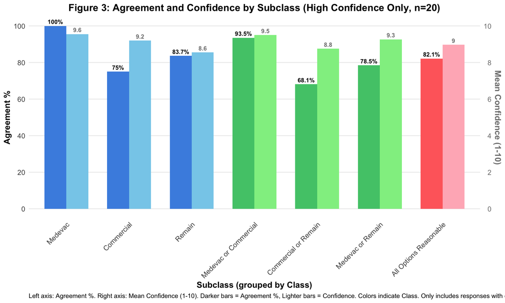

## Tables 4.1-4.3: Summary Statistics by Individual Vignette (Experienced Respondents Only, n=13)

These tables show detailed statistics for each vignette, including only responses from physicians with more than 5 years since training completion.

### Table 4.1: One Correct Answer (Experienced Respondents Only)

Table 4.1: Class A - One Correct Answer (>5 Years Experience)

| Subclass | Question Number | Medevac | Commercial | Remain | Modal Decision | Agreement % | Gwet's AC1 | Interpretation | Entropy | Mean Conf. |
| --- | --- | --- | --- | --- | --- | --- | --- | --- | --- | --- |
| Medevac | 1 | 100.0% (n=13) | 0.0% (n=0) | 0.0% (n=0) | Medevac | 100.0 | 1.000 | Perfect | 0.000 | 9.8 |
| Medevac | 4 | 92.3% (n=12) | 0.0% (n=0) | 7.7% (n=1) | Medevac | 92.3 | 0.821 | Very Good | 0.391 | 9.1 |
| Medevac | 13 | 100.0% (n=13) | 0.0% (n=0) | 0.0% (n=0) | Medevac | 100.0 | 1.000 | Perfect | 0.000 | 9.2 |
| Medevac | 19 | 100.0% (n=13) | 0.0% (n=0) | 0.0% (n=0) | Medevac | 100.0 | 1.000 | Perfect | 0.000 | 9.4 |
| Commercial | 9 | 0.0% (n=0) | 76.9% (n=10) | 23.1% (n=3) | Commercial | 76.9 | 0.404 | Moderate | 0.779 | 7.8 |
| Commercial | 15 | 53.8% (n=7) | 38.5% (n=5) | 7.7% (n=1) | Medevac | 53.8 | 0.165 | Slight | 1.296 | 7.9 |
| Remain | 8 | 7.7% (n=1) | 23.1% (n=3) | 69.2% (n=9) | Remain | 69.2 | 0.350 | Fair | 1.140 | 7.2 |
| Remain | 11 | 0.0% (n=0) | 30.8% (n=4) | 69.2% (n=9) | Remain | 69.2 | 0.196 | Slight | 0.890 | 7.4 |

### Table 4.2: Two Reasonable Options (Experienced Respondents Only)

Table 4.2: Class B - Two Reasonable Options (>5 Years Experience)

| Subclass | Question Number | Medevac | Commercial | Remain | Modal Decision | Agreement % | Gwet's AC1 | Interpretation | Entropy | Mean Conf. |
| --- | --- | --- | --- | --- | --- | --- | --- | --- | --- | --- |
| Medevac or Commercial | 7 | 92.3% (n=12) | 7.7% (n=1) | 0.0% (n=0) | Medevac | 92.3 | 0.821 | Very Good | 0.391 | 9.8 |
| Medevac or Commercial | 10 | 76.9% (n=10) | 23.1% (n=3) | 0.0% (n=0) | Medevac | 76.9 | 0.404 | Moderate | 0.779 | 7.8 |
| Commercial or Remain | 2 | 23.1% (n=3) | 53.8% (n=7) | 23.1% (n=3) | Commercial | 53.8 | 0.064 | Slight | 1.457 | 7.8 |
| Commercial or Remain | 5 | 0.0% (n=0) | 76.9% (n=10) | 23.1% (n=3) | Commercial | 76.9 | 0.404 | Moderate | 0.779 | 8.1 |
| Commercial or Remain | 6 | 23.1% (n=3) | 53.8% (n=7) | 23.1% (n=3) | Commercial | 53.8 | 0.064 | Slight | 1.457 | 6.9 |
| Commercial or Remain | 14 | 0.0% (n=0) | 30.8% (n=4) | 69.2% (n=9) | Remain | 69.2 | 0.196 | Slight | 0.890 | 7.3 |
| Medevac or Remain | 16 | 69.2% (n=9) | 0.0% (n=0) | 30.8% (n=4) | Medevac | 69.2 | 0.196 | Slight | 0.890 | 7.0 |
| Medevac or Remain | 17 | 46.2% (n=6) | 0.0% (n=0) | 53.8% (n=7) | Remain | 53.8 | -0.071 | None | 0.996 | 7.2 |
| Medevac or Remain | 18 | 23.1% (n=3) | 0.0% (n=0) | 76.9% (n=10) | Remain | 76.9 | 0.404 | Moderate | 0.779 | 8.8 |

### Table 4.3: Highly Ambiguous (Experienced Respondents Only)

Table 4.3: Class C - Highly Ambiguous (>5 Years Experience)

| Subclass | Question Number | Medevac | Commercial | Remain | Modal Decision | Agreement % | Gwet's AC1 | Interpretation | Entropy | Mean Conf. |
| --- | --- | --- | --- | --- | --- | --- | --- | --- | --- | --- |
| All Options Reasonable | 3 | 15.4% (n=2) | 0.0% (n=0) | 84.6% (n=11) | Remain | 84.6 | 0.619 | Good | 0.619 | 7.3 |
| All Options Reasonable | 12 | 46.2% (n=6) | 38.5% (n=5) | 15.4% (n=2) | Medevac | 46.2 | 0.037 | Slight | 1.460 | 6.0 |
| All Options Reasonable | 20 | 69.2% (n=9) | 15.4% (n=2) | 15.4% (n=2) | Medevac | 69.2 | 0.328 | Fair | 1.198 | 7.8 |

## Figure 4: Agreement and Confidence by Subclass (Experienced Respondents Only, n=13)

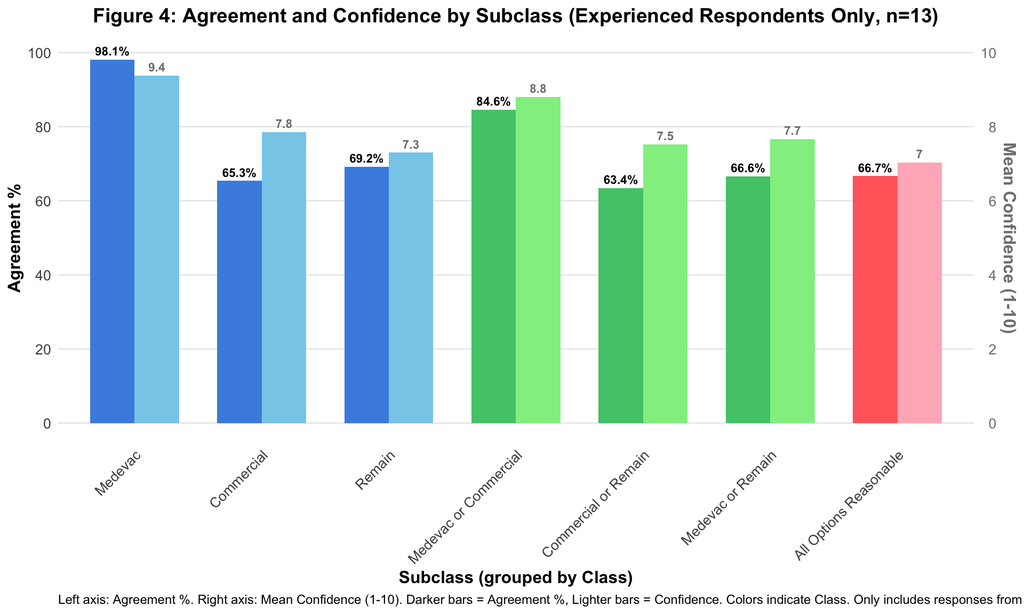